# STAT 331 Portfolio

## Program Efficiency

**PE-1: I can write concise code which does not repeat itself.**

- using a single function call

```r
# Lab 7, Problem 3.4

scaleFish <- blackFootFish %>%
  mutate(lengthRescale = rescale_01(length))

ggplot(data = scaleFish, aes(x = lengthRescale)) +
  geom_density()
```

- `across()`

```r
# Challenge 3, Comparing Male vs Female

hiphop_mean <- hiphop %>%
  group_by(sex) %>%
  summarize(across(intl:unclassifiable, ~mean(.x, na.rm = TRUE))) %>%
  pivot_longer(cols = "intl":"unclassifiable")
```

- `map()` functions

```r
# Lab 8, Step 4 (Revised)

christmas_song <- function(dataset, line, phrase_col) {

  song <- map_chr(.x = 1:line,
                  .f = ~sing_day(dataset, .x, phrase_col))

  return(glue::glue("{song}"))
}

christmas_song(xmas2, 12, "Full.Phrase")
```

**PE-2: I can write functions to reduce repetition in my code.**

- Example 1

```r
# Lab 8, Step 4 (Revised)

christmas_song <- function(dataset, line, phrase_col) {

  song <- map_chr(.x = 1:line,
                  .f = ~sing_day(dataset, .x, phrase_col))

  return(glue::glue("{song}"))
}

christmas_song(xmas2, 12, "Full.Phrase")
```

- Example 2

```r
# Lab 7, Problem 3.1

rescale_01 <- function(x) {
  stopifnot(is.numeric(x), length(x) > 1)

  max <- max(x, na.rm = TRUE)
  min <- min(x, na.rm = TRUE)

  x <- ((x - min) / (max - min))
  return(x)
}
```

**PE-3:I can use iteration to reduce repetition in my code.**

- `across()`

```r
# Challenge 3, Comparing Male vs Female

hiphop_mean <- hiphop %>%
  group_by(sex) %>%
  summarize(across(intl:unclassifiable, ~mean(.x, na.rm = TRUE))) %>%
  pivot_longer(cols = "intl":"unclassifiable")
```

- `map()` functions (Provide 2 Examples)

```r
# Lab 8, Step 4 (Revised)

christmas_song <- function(dataset, line, phrase_col) {

  song <- map_chr(.x = 1:line,
                  .f = ~sing_day(dataset, .x, phrase_col))

  return(glue::glue("{song}"))
}

christmas_song(xmas2, 12, "Full.Phrase")
```

```r
# Lab 8, 0.1 Step 2 (Revised)

xmas2 <- xmas %>%
 mutate(Full.Phrase = pmap_chr(.l = list(Day,
                                         Day.in.Words,
                                         Gift.Item,
                                         Verb,
                                         Adjective,
                                         Location),
                               .f = make_phrase))
```

**PE-4: I can use modern tools when carrying out my analysis.**

- Example 1

```r
# Lab 3, Problem 11 (revised)

hiphop_clean %>%
  filter(age < 20) %>%
  group_by(word) %>%
  summarise(Mean = mean(as.integer(familiarity))) %>%
  slice_max(Mean, n = 5)
hiphop_clean %>%
  filter(age < 20) %>%
  group_by(word) %>%
  summarise(Mean = mean(as.integer(familiarity))) %>%
  slice_min(Mean, n = 5)
```

- Example 2

```r
# Challenge 3, Comparing Male vs Female

hiphop_mean <- hiphop %>%
  group_by(sex) %>%
  summarize(across(intl:unclassifiable, ~mean(.x, na.rm = TRUE))) %>%
  pivot_longer(cols = "intl":"unclassifiable")
```

## Data Simulation & Modeling

**DSM-1: I can simulate data from a *variety* of probability models.**

- Example 1

```r
# Practice Activity 9.2, Warmup

qunif(0.95, min = 1.5, max = 3.5)

qnorm(0.1, mean = 4.6, sd = 0.8)

pnorm(5, mean = 4.6, sd = 0.8, lower.tail = FALSE)

pchisq(5, df = 4, lower.tail = FALSE)

sum(rnorm(100, mean = 4.6, sd = 0.8) < 4)
```

- Example 2

```r
# Practice Activity 9.2, Catching a Con

set.seed(1957)

music_man <- function(n_tromb, n_cor, n_reed){

  trombones <- rnorm(n_tromb, mean = 4.6, sd = 0.8)
  cornets <- runif(n_cor, min = 1.5, max = 3.5)
  reeds <- rchisq(n_reed, df = 4)

  return(sum(trombones, cornets, reeds))
}

my_weights <- map_dbl(.x = 1:1000,
                      .f = ~ music_man(n_tromb = 76,
                                       n_cor = 110,
                                       n_reed = 1035)
                      )

sum(my_weights < 4532)
```

**DSM-2: I can fit a linear regression and extract necessary summary measures.**

- Example 1

```r
# Lab 9, Problem 5 (Revised)

estReg <- allison_f |>
  lm(F ~ Year, data = _)
```

- Example 2

```r
# Practice Activity 9.1

modMys <- mystery |>
  lm(weight_before ~ weight_after, data = _)
```

## Revising My Thinking

I think I revised my thinking throughout this course by restructuring my approach to make code more user friendly. It’s easy to make a code block run and carry out tasks, but it takes extra effort to make code more tidy by adding spaces and hitting enter after certain characters. Additionally, efficiency isn’t something I was concerned about but condensing code to save a couple lines allows the computer to process the block faster. These were things I never really thought about that I’ve been growing on. When I move forward to my career or working with teams, I can’t present messy or inefficient code because it’s hard for people to read and makes work more inefficient.

Based on the code examples I’ve provided in my portfolio, I’ve revised my thinking by structuring my R code blocks cleanly and adding features, especially to my visualization, that makes my outputs more user friendly. When it comes to revising my thinking, I take into consideration the feedback given back to me from my peers and the feedback I am given from Dr. Theobold.

I went through and heavily edited multiple labs where I believe I now have mastered the skills of. I think the greatest way to prove growth is to tackle the assignment that was the hardest for myself. In particular, I’m submitting lab 4 as my portfolio revision because it had the most extensive feedback and errors. I didn’t want to walk away from this class without proving that I knew filtering joins() and I also know how crucial the concept of joins is in SQL - a skill I aim to develop as well.

## Extending My Thinking

I extended my thinking throughout this course by doing my own research and outsourcing R tricks to make my visualizations and code more clean and efficient. I’ve created comments in the original Quarto files that cited my sources for the code examples I’ve provided in this portfolio. Examples of also stepping up extending my thinking is in challenge 2 when I choose a more difficult level, or I tried spicing up my visualizations like in lab 4 and lab 7.

## Peer Support & Collaboration

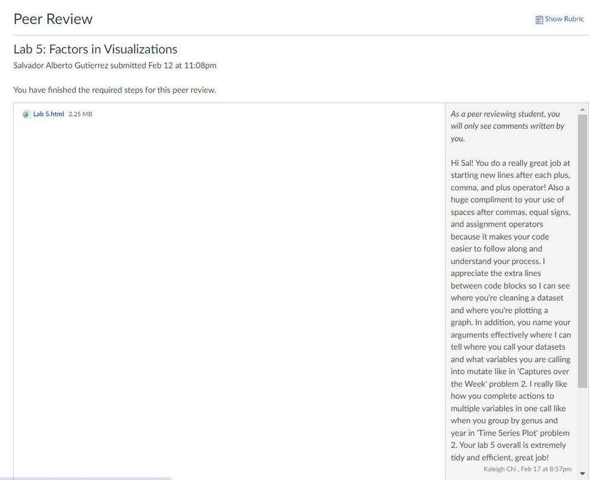

This is a Peer Review that I am proud of. I put a lot of thought into this review in regard to how tidy and efficient their code was. I made sure to follow the rubric and cited specific spots where I thought they did well.

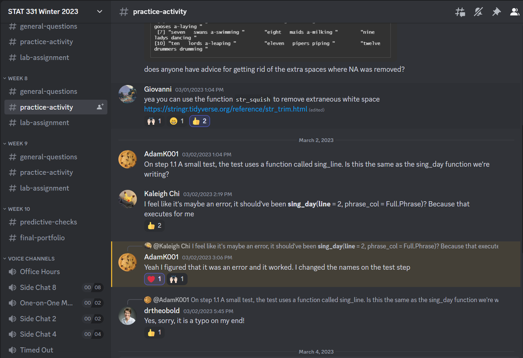

Another peer interaction I’m proud of. I’m stepping up from my interaction level on Discord from week 6, and I’m giving useful comments.

The screenshots above are examples of peer reviews I am proud of. I believe I have grown as a reviewer to give more thorough checks of my classmate’s codes and even cite where in their code I am proud of or I believe needs improvement. When I started off this quarter I wasn’t giving my feedback the most timely because I was up against the clock. I’ve been giving my reviews in a timely manner which I am proud of. I believe I take my reviews seriously and it’s important for me to provide feedback constructively where I can help someone improve without being discouraging.

In regards to group collaboration, I feel that I am always engaged with group work. My role thus far has always been the person supporting the drivers. I have my laptop on the side to search up anything the drivers need help on or read instructions. I have never overstepped my role of taking control of other’s keyboards or seat. I am also committed to the assignments in class. An example of this is when my groupmate and I set up a Zoom meeting to finish a Practice Activity because we were not on campus during a time we were both free.

Previously in my midterm portfolio, I said that I thought I lacked my interaction on Discord. I think I took steps to answer more questions and engage with my classmate’s questions because I realized I needed to step up in that aspect.